# Software Übungen

## Aufgabe 7

Betrachten Sie Produktionsfunktionen der Art

[figure not shown]

, wobei

[figure not shown]

ein Mass für Output ist,

[figure not shown]

Labor-Input ist und

[figure not shown]

```r
# Einlesen der Daten für Aufgabe 7
production <- read.csv("data/production.csv")
```

### a) Testen Sie die constant returns to scale Hypothese, d.h., .\

[figure not shown]

```r
fit_production <- lm(log(Q) ~ log(L) + log(K), data = production)
fit_constant_returns <- lm(I(log(Q) - log(K)) ~ I(log(L) - log(K)), data = production)
summary(fit_production)
```

```
##
## Call:
## lm(formula = log(Q) ~ log(L) + log(K), data = production)
##
## Residuals:
##      Min       1Q   Median       3Q      Max
## -0.55363 -0.09179 -0.00146  0.13888  0.49386
##
## Coefficients:
##             Estimate Std. Error t value Pr(>|t|)
## (Intercept)  -0.1287     0.5461  -0.236    0.815
## log(L)        0.5590     0.8164   0.685    0.499
## log(K)        0.4877     0.7039   0.693    0.494
##
## Residual standard error: 0.2167 on 30 degrees of freedom
## Multiple R-squared:  0.6883, Adjusted R-squared:  0.6675
## F-statistic: 33.12 on 2 and 30 DF,  p-value: 2.547e-08
```

```r
summary(fit_constant_returns)
```

```
##
## Call:
## lm(formula = I(log(Q) - log(K)) ~ I(log(L) - log(K)), data = production)
##
## Residuals:
##     Min      1Q  Median      3Q     Max
## -0.5514 -0.1054 -0.0100  0.1289  0.4818
##
## Coefficients:
##                    Estimate Std. Error t value Pr(>|t|)
## (Intercept)         0.02010    0.05293   0.380    0.707
## I(log(L) - log(K))  0.39840    0.55927   0.712    0.482
##
## Residual standard error: 0.2135 on 31 degrees of freedom
## Multiple R-squared:  0.01611,    Adjusted R-squared:  -0.01563
## F-statistic: 0.5075 on 1 and 31 DF,  p-value: 0.4816
```

Somit haben wir

[figure not shown]

und

[figure not shown]

. Die Test-Statistik ist dann

[figure not shown]

Der

[figure not shown]

-Wert ist damit

[figure not shown]

. Somit ist die “constant returns to scale” Hypothese plausibel. Alternativ können wir den

[figure not shown]

-Test auch “direkt” ausführen:

```r
car::linearHypothesis(fit_production, hypothesis.matrix = c(0, 1, 1), rhs = 1)
```

```
## Linear hypothesis test
##
## Hypothesis:
## log(L)  + log(K) = 1
##
## Model 1: restricted model
## Model 2: log(Q) ~ log(L) + log(K)
##
##   Res.Df    RSS Df Sum of Sq      F Pr(>F)
## 1     31 1.4129
## 2     30 1.4094  1 0.0035203 0.0749 0.7862
```

Die leichten Unterschiede hierbei sind auf die Rundungsfehler zurückzuführen, wenn der Test “von Hand” ausgeführt wird.

### b) Man beobachtet und . Finden Sie ein 95% Vorhersage-Intervall für unter der Annahme, dass die constant returns to scale Hypothese gültig ist. Vertrauen Sie diesem Intervall? (Achtung: etwas trickreich…) Bemerkung: Gehen Sie von Homoskedastie hier aus.

[figure not shown]

[figure not shown]

[figure not shown]

```r
predict(fit_constant_returns, data.frame(K = 20, L = 25, Q = 0), se = T)
```

```
## $fit
##         1
## 0.1089987
##
## $se.fit
## [1] 0.09470963
##
## $df
## [1] 31
##
## $residual.scale
## [1] 0.2134894
```

```r
qt(0.975, 31)
```

```
## [1] 2.039513
```

```r
0.109 + 2.039513 * sqrt(0.0947^2 + 0.21349^2)
```

```
## [1] 0.5853303
```

```r
exp(-0.3673303 + log(20))
```

```
## [1] 13.85162
```

```r
exp(0.5853303 + log(20))
```

```
## [1] 35.91168
```

Das geschützte Modell unter

[figure not shown]

gibt uns ein Vorhersage-Intervall für

[figure not shown]

. Um dieses in ein Vorhersage-Intervall für

[figure not shown]

umzuwandeln, müssen wir auf jeden Endpunkt die Invers-Transformation

[figure not shown]

Schneller erhalten wir das Vorhersage-Intervall in der transformierten Welt wie folgt:

```r
exp(predict(fit_constant_returns, data.frame(K = 20, L = 25, Q = 0),
    interval = "prediction", level = 0.95
) + log(20))
```

```
##        fit     lwr      upr
## 1 22.30322 13.8515 35.91188
```

Das Endergebnis ist (bis auf kleine Rundungsfehler) natürlich identisch.

Allerdings ist der Stichprobenumfang recht klein mit

[figure not shown]

und das Normal-Quantil-Diagramm zeigt das “Heavy Tails” Muster. Man sollte dem Vorhersage-Intervall daher nicht übermässig vertrauen.

Gefahrendiagramm:

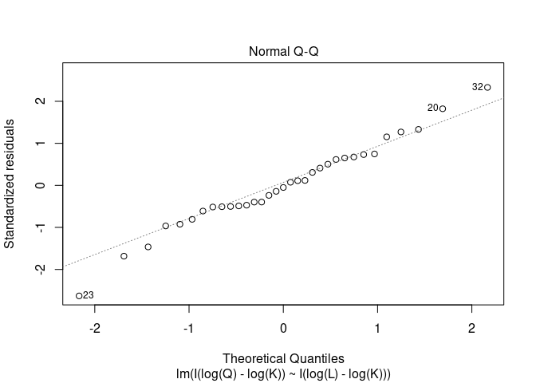

```r
plot(fit_constant_returns, which = 2)
```